# Scanpy/PAGA - YS & AGM

- Date: 05/03/2022
- Goal: import pre-processed data from Seurat to Scanpy and run PAGA
- Reference: https://scanpy-tutorials.readthedocs.io/en/latest/paga-paul15.html
- Convert from Seurat: https://github.com/LuckyMD/Code_snippets/blob/master/Seurat_to_anndata.ipynb

How to install library

```python
#conda install seaborn scikit-learn statsmodels numba pytables
#conda install -c conda-forge python-igraph leidenalg
```

*Import libraries*

```python
import os
import fa2
import sys
import numpy as np
import pandas as pd
import matplotlib.pyplot as pl
from matplotlib import rcParams
import scanpy as sc
import loompy
sc.logging.print_versions()
```

[output not shown]

[output cut: 32 more lines]

[output not shown]

*Set parameters*

```python
# Change directory
os.getcwd()
os.chdir('/Users/zfadlullah/Desktop/05_Scanpy/')
```

```python
sc.settings.verbosity = 3  # verbosity: errors (0), warnings (1), info (2), hints (3)
sc.logging.print_versions()
sc.settings.set_figure_params(dpi=100, frameon=False, figsize=(4,4))
results_file = './write/PAGA.h5ad'
```

[output not shown]

[output cut: 43 more lines]

[output not shown]

## Load data

```python
# scanpy read function (give error)
adata = sc.read_loom("/Users/zfadlullah/Desktop/05_Scanpy/seu_allGenes_with_mes_EMP_LMP.loom")
```

```python
# Print content
adata
```

```
AnnData object with n_obs × n_vars = 1687 × 20717
    obs: 'Barcode', 'ClusterID', 'ClusterName', 'YS_clus', 'condition', 'nCount_RNA', 'nFeature_RNA', 'orig_ident'
    var: 'Selected', 'vst_mean', 'vst_variable', 'vst_variance', 'vst_variance_expected', 'vst_variance_standardized'
    layers: 'norm_data', 'scale_data'
```

Let us work with a higher precision than the default ‘float32’ to ensure exactly the same results across different computational platforms.

```python
adata.X = adata.X.astype('float64')  # this is not required and results will be comparable without it
```

Save a secondary object for later use if required

```python
import copy
sdata = copy.deepcopy(adata)
```

```python
### Use this if need to copy object back
adata = copy.deepcopy(sdata)
```

## Dim redcution, clustering

Here we re-do the clustering based on leiden clusters. Then we run PAGA on leiden clusters

```
normalizing counts per cell
    finished (0:00:00)
extracting highly variable genes
    finished (0:00:00)
--> added
    'highly_variable', boolean vector (adata.var)
    'means', float vector (adata.var)
    'dispersions', float vector (adata.var)
    'dispersions_norm', float vector (adata.var)
```

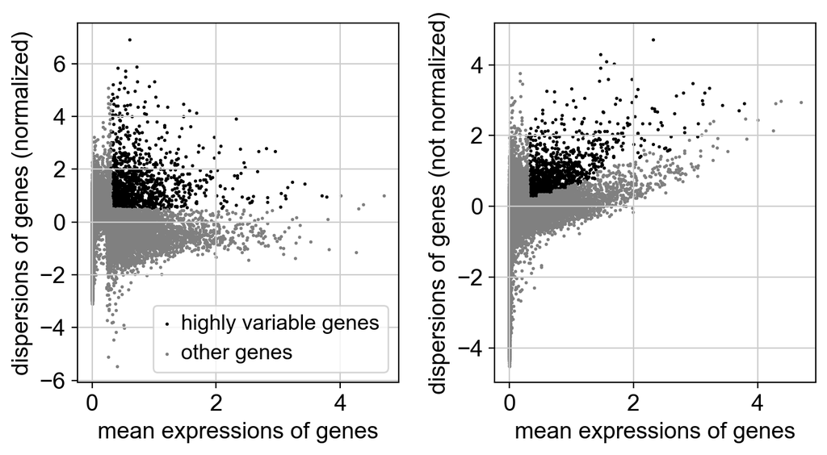

```python
sc.pp.normalize_total(adata, target_sum=1e4)
sc.pp.log1p(adata)


sc.pp.highly_variable_genes(adata, min_mean=0.3, max_mean=4, min_disp=0.5)

sc.pl.highly_variable_genes(adata)
```

Scale each gene to unit variance

```python
sc.pp.scale(adata, max_value=10)
```

```
... as `zero_center=True`, sparse input is densified and may lead to large memory consumption
```

Extract the HVG

```python
adata.var.to_csv('./output/GeneData_mes_emp_lmp.csv')
```

```python
adata.var
```

|  | Selected | vst_mean | vst_variable | vst_variance | vst_variance_expected | vst_variance_standardized | highly_variable | means | dispersions | dispersions_norm | mean | std |
| --- | --- | --- | --- | --- | --- | --- | --- | --- | --- | --- | --- | --- |
| Xkr4 | 0.0 | 0.072910 | 0 | 4.424693 | 1.595089 | 1.399092 | False | 0.001950 | 0.723884 | 1.253002 | 0.001123 | 0.032739 |
| Gm19938 | 0.0 | 0.076467 | 0 | 1.813248 | 1.714132 | 1.057823 | False | 0.001238 | -1.089315 | -0.254099 | 0.001071 | 0.017329 |
| Gm37381 | 0.0 | 0.013634 | 0 | 0.020573 | 0.078803 | 0.261070 | False | 0.000197 | -3.834594 | -2.535930 | 0.000195 | 0.002040 |
| Rp1 | 1.0 | 0.229401 | 1 | 14.932516 | 7.502858 | 1.990244 | False | 0.003415 | -0.028389 | 0.627725 | 0.002448 | 0.038649 |
| Sox17 | 1.0 | 98.064613 | 1 | 34535.210938 | 9632.229492 | 3.585381 | True | 0.922258 | 1.495083 | 2.487701 | 0.575538 | 0.758276 |
| ... | ... | ... | ... | ... | ... | ... | ... | ... | ... | ... | ... | ... |
| CAAA01147332.1 | 0.0 | 0.107291 | 0 | 0.241744 | 2.775553 | 0.087098 | False | 0.001633 | -3.293880 | -2.086497 | 0.001604 | 0.007545 |
| AC149090.1 | 0.0 | 41.898045 | 0 | 5090.038086 | 3086.786133 | 1.648977 | True | 0.520564 | 0.702604 | 1.295560 | 0.376076 | 0.482916 |
| GFP | 0.0 | 3.346769 | 0 | 122.697594 | 197.108459 | 0.622488 | False | 0.047667 | -0.695806 | 0.072979 | 0.039738 | 0.116697 |
| RFP | 1.0 | 59.684647 | 1 | 13965.208008 | 4872.312012 | 2.866238 | True | 0.600378 | 1.035404 | 2.023940 | 0.377864 | 0.597331 |
| dTomato | 0.0 | 0.708951 | 0 | 21.562334 | 30.978409 | 0.696044 | False | 0.011683 | -0.703299 | 0.066751 | 0.009672 | 0.058399 |

20717 rows × 12 columns

Here we do some manual filtering. We previosly identified batch related genes. Now we remove them

```python
# We read this gene list

#glist = pd.read_csv("data/HVG_manual_filter_mes_EMP_LMP.csv")
glist = pd.read_csv("data/GeneData_hvg_mes_emp_lmp.csv")
glist['HVG']
#adata.var_names
# Subset
adata_sub = adata[:,glist['HVG'][:]]
adata_sub
```

```
View of AnnData object with n_obs × n_vars = 1687 × 1164
    obs: 'Barcode', 'ClusterID', 'ClusterName', 'YS_clus', 'condition', 'nCount_RNA', 'nFeature_RNA', 'orig_ident'
    var: 'Selected', 'vst_mean', 'vst_variable', 'vst_variance', 'vst_variance_expected', 'vst_variance_standardized', 'highly_variable', 'means', 'dispersions', 'dispersions_norm', 'mean', 'std'
    uns: 'log1p', 'hvg'
    layers: 'norm_data', 'scale_data'
```

```python
#adata_sub  = adata
```

Run PCA

```python
sc.tl.pca(adata_sub, svd_solver='arpack')
sc.pp.neighbors(adata_sub, n_neighbors=25, n_pcs=50)
```

```
computing PCA
    on highly variable genes
    with n_comps=50
    finished (0:00:00)
computing neighbors
    using 'X_pca' with n_pcs = 50
    finished: added to `.uns['neighbors']`
    `.obsp['distances']`, distances for each pair of neighbors
    `.obsp['connectivities']`, weighted adjacency matrix (0:00:06)
```

```python
#sc.tl.leiden(adata, resolution=3)
sc.tl.leiden(adata_sub, resolution=2)
```

```
running Leiden clustering
    finished: found 17 clusters and added
    'leiden', the cluster labels (adata.obs, categorical) (0:00:00)
```

```
... storing 'ClusterName' as categorical
... storing 'YS_clus' as categorical
... storing 'condition' as categorical
... storing 'orig_ident' as categorical
```

```
running PAGA
    finished: added
    'paga/connectivities', connectivities adjacency (adata.uns)
    'paga/connectivities_tree', connectivities subtree (adata.uns) (0:00:00)
--> added 'pos', the PAGA positions (adata.uns['paga'])
```

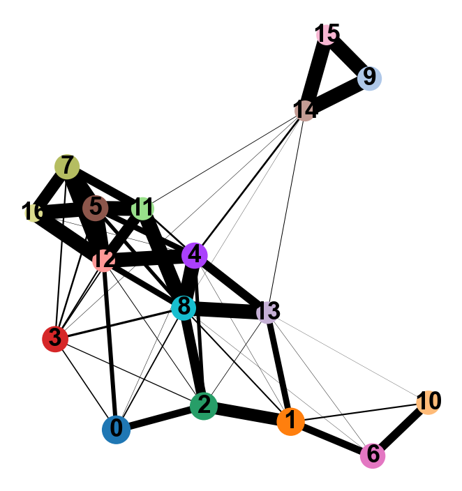

```
computing UMAP
    finished: added
    'X_umap', UMAP coordinates (adata.obsm) (0:00:03)
```

```python
sc.tl.paga(adata_sub, groups='leiden')
sc.pl.paga(adata_sub)  # remove `plot=False` if you want to see the coarse-grained graph
sc.tl.umap(adata_sub, init_pos='paga')
```

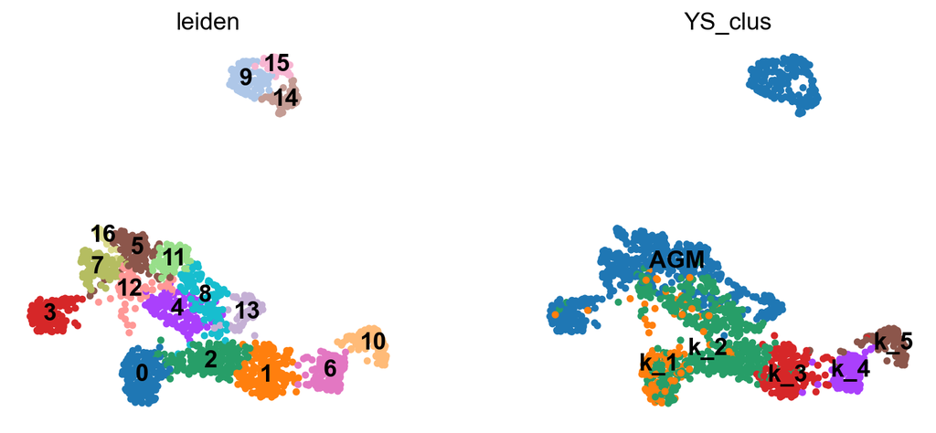

```python
sc.pl.umap(adata_sub, color=['leiden', 'YS_clus'],legend_loc='on data')
```

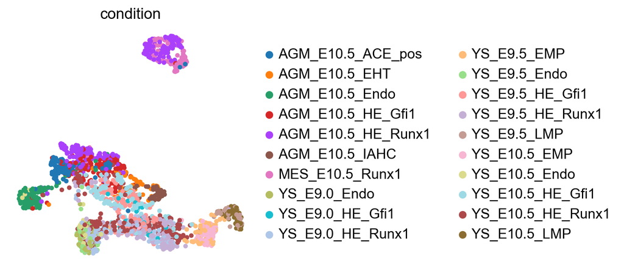

```python
sc.pl.umap(adata_sub, color=['condition'])
```

```python
# Check number of cells in each cluster
#adata_sub.obs['leiden'].value_counts()
```

Examine some genes

```python
#sc.pl.umap(adata_sub, color=['Gfi1', 'Runx1', 'Mcam'])
#sc.pl.umap(adata_sub, color=['Aplnr', 'Lyve1', 'Gja4'])
#sc.pl.umap(adata_sub, color=['Ace', 'Fbln5', 'Dlk1'])
```

```python
#adata
adata_sub.obs[['leiden']].to_csv(
     './output/allcells_leiden.csv')

# Write UMAP
adata_sub.obsm.to_df()[['X_umap1', 'X_umap2']].to_csv(
     './output/allcells_UMAP_cord.csv')
```

## Filtering

We manually removed the following cells from the main adata object;

1) AGM mesenchymal population  
2) YS cluster k4 and k5

```python
adata = copy.deepcopy(sdata)
```

```python
# Add cluster to the adata
adata.obs['leiden'] = adata_sub.obs['leiden']
```

```python
# Remove mesencyme and venous cluster
adata_sub2 = adata[-adata.obs['leiden'].isin([
    '9', '15', '14', '3'])]
# Remove YS cluster k4 and k5
adata_sub2 = adata_sub2[-adata_sub2.obs['YS_clus'].isin([
    'k_4', 'k_5'])]
```

```python
adata_sub2.obs['condition'].value_counts()
```

```
YS_E10.5_HE_Runx1     184
AGM_E10.5_HE_Runx1    136
AGM_E10.5_HE_Gfi1     120
YS_E9.5_HE_Runx1      116
YS_E9.5_HE_Gfi1       114
YS_E10.5_HE_Gfi1      113
YS_E9.0_HE_Runx1       99
AGM_E10.5_ACE_pos      86
AGM_E10.5_IAHC         42
AGM_E10.5_EHT          40
YS_E9.0_Endo           35
YS_E9.5_Endo           32
YS_E10.5_Endo          30
YS_E9.0_HE_Gfi1        19
AGM_E10.5_Endo         11
YS_E9.5_EMP             7
MES_E10.5_Runx1         4
YS_E10.5_EMP            1
YS_E9.5_LMP             1
Name: condition, dtype: int64
```

```python
# Remove remnant populations
adata_sub2 = adata_sub2[-adata_sub2.obs['condition'].isin([
    'YS_E9.5_LMP', 'YS_E10.5_EMP', 'MES_E10.5_Runx1', 'YS_E9.5_EMP'])]
```

```python
adata_sub2.obs['condition'].value_counts()
```

```
YS_E10.5_HE_Runx1     184
AGM_E10.5_HE_Runx1    136
AGM_E10.5_HE_Gfi1     120
YS_E9.5_HE_Runx1      116
YS_E9.5_HE_Gfi1       114
YS_E10.5_HE_Gfi1      113
YS_E9.0_HE_Runx1       99
AGM_E10.5_ACE_pos      86
AGM_E10.5_IAHC         42
AGM_E10.5_EHT          40
YS_E9.0_Endo           35
YS_E9.5_Endo           32
YS_E10.5_Endo          30
YS_E9.0_HE_Gfi1        19
AGM_E10.5_Endo         11
Name: condition, dtype: int64
```

## Re-do paga

```python
adata_sub2
```

```
View of AnnData object with n_obs × n_vars = 1177 × 20717
    obs: 'Barcode', 'ClusterID', 'ClusterName', 'YS_clus', 'condition', 'nCount_RNA', 'nFeature_RNA', 'orig_ident', 'leiden'
    var: 'Selected', 'vst_mean', 'vst_variable', 'vst_variance', 'vst_variance_expected', 'vst_variance_standardized'
    layers: 'norm_data', 'scale_data'
```

```
normalizing counts per cell
    finished (0:00:00)
If you pass `n_top_genes`, all cutoffs are ignored.
extracting highly variable genes
    finished (0:00:03)
--> added
    'highly_variable', boolean vector (adata.var)
    'means', float vector (adata.var)
    'dispersions', float vector (adata.var)
    'dispersions_norm', float vector (adata.var)
```

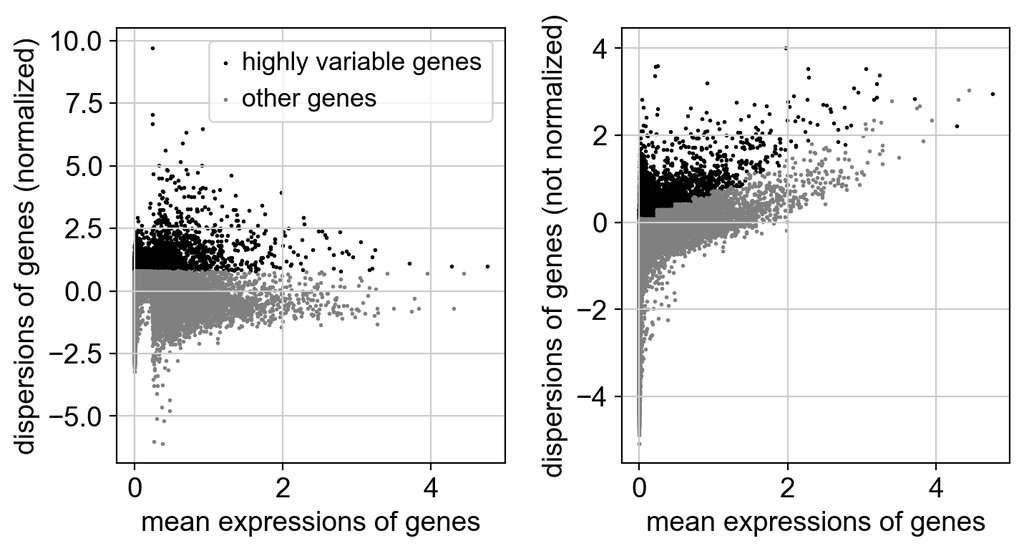

```python
sc.pp.normalize_total(adata_sub2, target_sum=1e4)
sc.pp.log1p(adata_sub2)


#sc.pp.highly_variable_genes(adata_sub2, min_mean=0.2, max_mean=5, min_disp=0.5)
sc.pp.highly_variable_genes(adata_sub2, n_top_genes=3500)

sc.pl.highly_variable_genes(adata_sub2)
```

```python
sc.pp.scale(adata_sub2, max_value=10)
```

```
... as `zero_center=True`, sparse input is densified and may lead to large memory consumption
```

```python
adata_sub2.var.to_csv('./output/GeneData_noMES_noEMPnoLMP.csv')
```

```python
# Read the HVG list where dropouts are removed, non-chr genes, batch related genes and cell cycle genes are removed
# We read this gene list

glist = pd.read_csv("data/GeneData_hvg_NO_mesEMPLMP.csv")
#glist['HVG']
#adata.var_names
# Subset
adata_sub2 = adata_sub2[:,glist['HVG'][:]]
adata_sub2
```

```
View of AnnData object with n_obs × n_vars = 1177 × 3109
    obs: 'Barcode', 'ClusterID', 'ClusterName', 'YS_clus', 'condition', 'nCount_RNA', 'nFeature_RNA', 'orig_ident', 'leiden'
    var: 'Selected', 'vst_mean', 'vst_variable', 'vst_variance', 'vst_variance_expected', 'vst_variance_standardized', 'highly_variable', 'means', 'dispersions', 'dispersions_norm', 'mean', 'std'
    uns: 'log1p', 'hvg'
    layers: 'norm_data', 'scale_data'
```

Run PCA

```python
sc.tl.pca(adata_sub2, svd_solver='arpack')
#sc.pp.neighbors(adata_sub2, n_neighbors=30, n_pcs=50)
sc.pp.neighbors(adata_sub2, n_neighbors=20, n_pcs=30)
```

```
computing PCA
    on highly variable genes
    with n_comps=50
    finished (0:00:00)
computing neighbors
    using 'X_pca' with n_pcs = 30
    finished: added to `.uns['neighbors']`
    `.obsp['distances']`, distances for each pair of neighbors
    `.obsp['connectivities']`, weighted adjacency matrix (0:00:00)
```

Clustering

```python
#sc.tl.leiden(adata_sub2, resolution=2)
sc.tl.leiden(adata_sub2, resolution=1.6)
```

```
running Leiden clustering
    finished: found 14 clusters and added
    'leiden', the cluster labels (adata.obs, categorical) (0:00:00)
```

```
... storing 'ClusterName' as categorical
... storing 'YS_clus' as categorical
... storing 'condition' as categorical
... storing 'orig_ident' as categorical
```

```
running PAGA
    finished: added
    'paga/connectivities', connectivities adjacency (adata.uns)
    'paga/connectivities_tree', connectivities subtree (adata.uns) (0:00:00)
--> added 'pos', the PAGA positions (adata.uns['paga'])
```

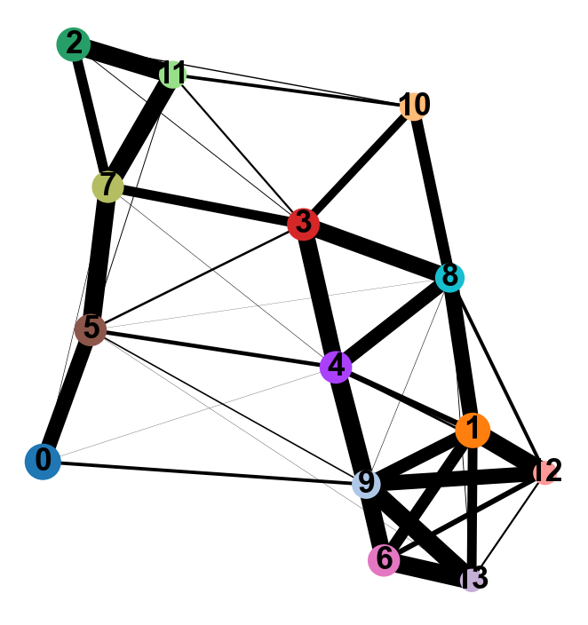

```
computing UMAP
    finished: added
    'X_umap', UMAP coordinates (adata.obsm) (0:00:02)
```

```python
sc.tl.paga(adata_sub2, groups='leiden')
sc.pl.paga(adata_sub2)  # remove `plot=False` if you want to see the coarse-grained graph
sc.tl.umap(adata_sub2, init_pos='paga')
```

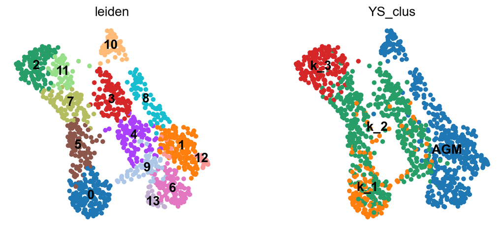

```python
sc.pl.umap(adata_sub2, color=['leiden', 'YS_clus'],legend_loc='on data')
```

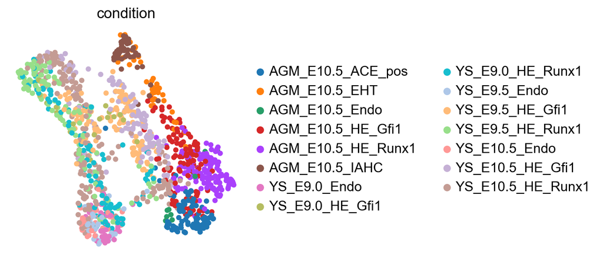

```python
sc.pl.umap(adata_sub2, color=['condition'])
```

```python
#sc.tl.embedding_density(adata_sub2, basis='umap', groupby='condition')
#sc.pl.embedding_density(adata_sub2, basis='umap', key='condition')
```

```python
# Check number of cells in each cluster
adata_sub2.obs['leiden'].value_counts()
```

```
0     159
1     142
2     122
3     100
4      98
5      96
6      95
7      92
8      64
9      58
10     53
11     49
12     26
13     23
Name: leiden, dtype: int64
```

### Merging clusters and re-computing UMAP

```python
# merge the lowest number of clsuters
#adata_sub2.obs['leiden'] = adata_sub2.obs['leiden'].replace({'12': '1', '13':'6'})
```

```python
#sc.tl.paga(adata_sub2, groups='leiden')
#sc.pl.paga(adata_sub2)  # remove `plot=False` if you want to see the coarse-grained graph
#sc.tl.umap(adata_sub2, init_pos='paga')
```

```python
#sc.pl.umap(adata_sub2, color=['leiden', 'YS_clus'],legend_loc='on data')
```

```python
#sc.pl.umap(adata_sub2, color=['condition'])
```

```python
#sc.pl.violin(adata_sub2, ['Gfi1', 'Sox17'], groupby='leiden')
```

### Export the coordinates

```python
#adata
adata_sub2.obs[['leiden']].to_csv(
     './output/noMES_leiden.csv')

# Write UMAP
adata_sub2.obsm.to_df()[['X_umap1', 'X_umap2']].to_csv(
     './output/noMES_UMAP_cord.csv')
```

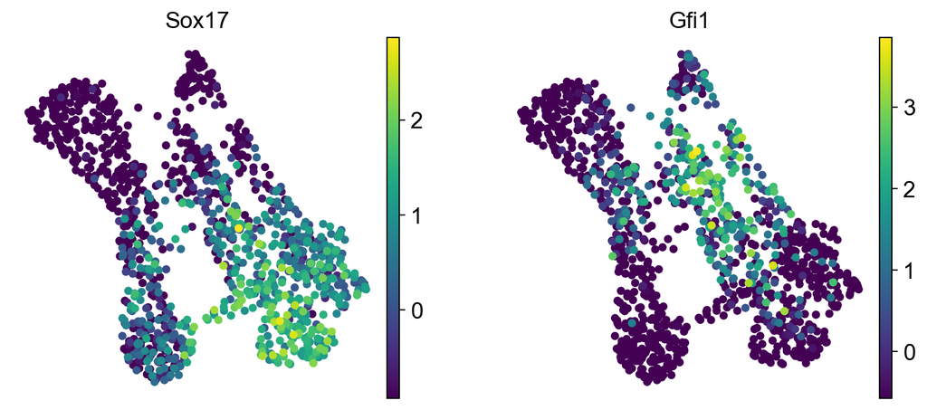

```python
sc.pl.umap(adata_sub2, color=['Sox17', "Gfi1"])
#sc.pl.umap(adata_sub2, color=['Lyve1', 'Mcam'])
```

### Export PAGA (based on UMAP)

To save the PAGA results we run the scrip below

```python
import os
import json
```

```python
# Get row names
indexNamesArr = adata.obs.index.values
# convert ndarray to list
listOfRowIndexLabels = list(indexNamesArr)
adata.obs["Cell"] = listOfRowIndexLabels
```

```python
#clust_embedding = pd.DataFrame(adata.uns['paga']['pos'], columns=['X', 'Y'])
#clust_embedding['leiden'] = adata.obs['leiden'].unique()
#clust_embedding = clust_embedding[['leiden', 'X', 'Y']]

#adata.uns['paga']
#adata.obs['leiden'].unique()
clust_con = adata.uns['paga']['connectivities'].toarray()

adata.obs['leiden'].cat.categories
```

```python
out_dir = 'output_all/paga_umap'
if not os.path.exists(out_dir):
    os.makedirs(out_dir)

def con2edges(con, names=None, sparse=True):
    print('Converting connectivity matrix to edges...')
    n = con.shape[0]
    edges = pd.DataFrame(columns=['From', 'To', 'Connectivity'])

    for i in range(n):
        for j in range(i + 1, n):
            if names is not None:
                fr = names[i]
                to = names[j]
            else:
                fr = str(i)
                to = str(j)

            connectivity = con[i, j]
            if sparse and connectivity == 0:
                continue

            entry = {'From' : fr, 'To' : to,
                     'Connectivity' : con[i, j]}
            edges = edges.append(entry, ignore_index=True)

    return edges

print('Outputting cluster edges...')
clust_con = adata.uns['paga']['connectivities'].toarray()
clust_edges = con2edges(clust_con)
clust_edges.to_csv(os.path.join(out_dir, 'cluster_edges.csv'),
                   index=False)

print('Outputting cluster tree edges...')
clust_tree_con = adata.uns['paga']['connectivities_tree'].toarray()
clust_tree_edges = con2edges(clust_tree_con)
clust_tree_edges.to_csv(os.path.join(out_dir, 'cluster_tree_edges.csv'),
                        index=False)

print('Outputting cluster embedding...')
clust_embedding = pd.DataFrame(adata.uns['paga']['pos'], columns=['X', 'Y'])
#clust_embedding['leiden'] = range(clust_embedding.shape[0])
#clust_embedding = clust_embedding[['leiden', 'X', 'Y']]

clust_embedding['leiden_default'] = range(clust_embedding.shape[0])
clust_embedding['leiden'] = adata.obs['leiden'].unique()
clust_embedding = clust_embedding[['leiden_default','leiden', 'X', 'Y']]

clust_embedding.to_csv(os.path.join(out_dir, 'cluster_embedding.csv'),
                       index=False)

print('Outputting cell edges...')
cells = adata.obs['Cell']
cell_con = adata.uns['neighbors']['connectivities']
cell_edges = pd.DataFrame(columns=['From', 'To', 'Connectivity'])
n_rows = len(cell_con.indptr)

for i in range(len(cell_con.indptr) - 1):
    row_ind = cell_con.indices[cell_con.indptr[i]:cell_con.indptr[i + 1]]
    print(f'\r\tRow {i} of {n_rows}', end='')
    for k, j in enumerate(row_ind):
        if j > i:
            con = cell_con.data[cell_con.indptr[i] + k]
            fr = cells[i]
            to = cells[j]
            entry = {'From' : fr, 'To' : to, 'Connectivity' : con}
            cell_edges = cell_edges.append(entry, ignore_index=True)
print('\n')

cell_edges.to_csv(os.path.join(out_dir, 'cell_edges.csv'),
                  index=False)

print('Outputting cell embedding...')
x = adata.obsm['X_umap'][:, 0]
y = adata.obsm['X_umap'][:, 1]
cell_embedding = pd.DataFrame({'Cell' : cells, 'X' : x, 'Y' : y})
cell_embedding.to_csv(os.path.join(out_dir, 'cell_embedding.csv'),
                      index=False)

print('Done!')
```

## Force directed graph PAGA

```
drawing single-cell graph using layout 'fa'
    finished: added
    'X_draw_graph_fa', graph_drawing coordinates (adata.obsm) (0:00:03)
```

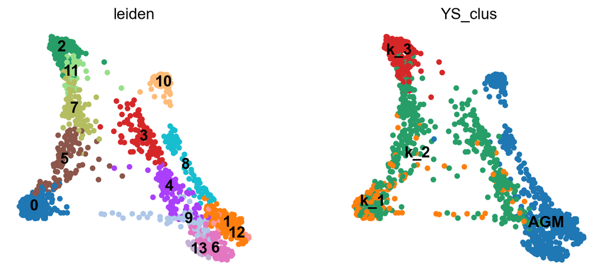

```python
sc.tl.draw_graph(adata_sub2, init_pos='paga')
sc.pl.draw_graph(adata_sub2, color=['leiden', "YS_clus"],legend_loc='on data')
```

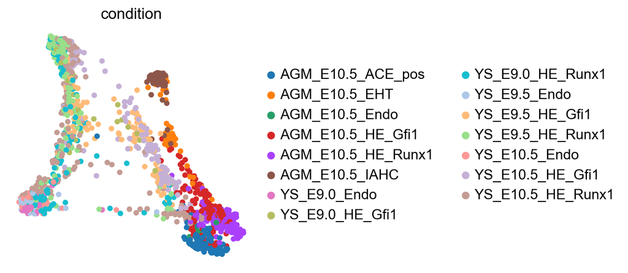

```python
sc.pl.draw_graph(adata_sub2, color=['condition'])
```

```python
sc.pl.paga_compare(
    adata, threshold=0.0, title='', right_margin=0.2, size=10, edge_width_scale=1.5,
    legend_fontsize=12, fontsize=12, frameon=False, edges=True, save=True)
```

## Export

Follow script available here: https://lazappi.github.io/phd-thesis-analysis/05-paga.html

```python
import os
import json
```

```python
# Get row names
indexNamesArr = adata.obs.index.values
# convert ndarray to list
listOfRowIndexLabels = list(indexNamesArr)
adata.obs["Cell"] = listOfRowIndexLabels
```

```python
out_dir = 'output_all/paga_force'
if not os.path.exists(out_dir):
    os.makedirs(out_dir)

def con2edges(con, names=None, sparse=True):
    print('Converting connectivity matrix to edges...')
    n = con.shape[0]
    edges = pd.DataFrame(columns=['From', 'To', 'Connectivity'])

    for i in range(n):
        for j in range(i + 1, n):
            if names is not None:
                fr = names[i]
                to = names[j]
            else:
                fr = str(i)
                to = str(j)

            connectivity = con[i, j]
            if sparse and connectivity == 0:
                continue

            entry = {'From' : fr, 'To' : to,
                     'Connectivity' : con[i, j]}
            edges = edges.append(entry, ignore_index=True)

    return edges

print('Outputting cluster edges...')
clust_con = adata.uns['paga']['connectivities'].toarray()
clust_edges = con2edges(clust_con)
clust_edges.to_csv(os.path.join(out_dir, 'cluster_edges.csv'),
                   index=False)

print('Outputting cluster tree edges...')
clust_tree_con = adata.uns['paga']['connectivities_tree'].toarray()
clust_tree_edges = con2edges(clust_tree_con)
clust_tree_edges.to_csv(os.path.join(out_dir, 'cluster_tree_edges.csv'),
                        index=False)

print('Outputting cluster embedding...')
clust_embedding = pd.DataFrame(adata.uns['paga']['pos'], columns=['X', 'Y'])
clust_embedding['leiden'] = range(clust_embedding.shape[0])
clust_embedding = clust_embedding[['leiden', 'X', 'Y']]

clust_embedding.to_csv(os.path.join(out_dir, 'cluster_embedding.csv'),
                       index=False)

print('Outputting cell edges...')
cells = adata.obs['Cell']
cell_con = adata.uns['neighbors']['connectivities']
cell_edges = pd.DataFrame(columns=['From', 'To', 'Connectivity'])
n_rows = len(cell_con.indptr)

for i in range(len(cell_con.indptr) - 1):
    row_ind = cell_con.indices[cell_con.indptr[i]:cell_con.indptr[i + 1]]
    print(f'\r\tRow {i} of {n_rows}', end='')
    for k, j in enumerate(row_ind):
        if j > i:
            con = cell_con.data[cell_con.indptr[i] + k]
            fr = cells[i]
            to = cells[j]
            entry = {'From' : fr, 'To' : to, 'Connectivity' : con}
            cell_edges = cell_edges.append(entry, ignore_index=True)
print('\n')

cell_edges.to_csv(os.path.join(out_dir, 'cell_edges.csv'),
                  index=False)

print('Outputting cell embedding...')
x = adata.obsm['X_draw_graph_fa'][:, 0]
y = adata.obsm['X_draw_graph_fa'][:, 1]
cell_embedding = pd.DataFrame({'Cell' : cells, 'X' : x, 'Y' : y})
cell_embedding.to_csv(os.path.join(out_dir, 'cell_embedding.csv'),
                      index=False)

print('Done!')
```

## Future work

To map UMAP into excisting reference https://scanpy-tutorials.readthedocs.io/en/latest/integrating-data-using-ingest.html or https://umap.scikit-tda.org/supervised.html#training-with-labels-and-embedding-unlabelled-test-data-metric-learning-with-umap